# Peer-graded Assignment: Regression models

Steven Michiels

4/20/2020

You work for Motor Trend, a magazine about the automobile industry. Looking at a data set of a collection of cars, they are interested in exploring the relationship between a set of variables and miles per gallon (MPG) (outcome). They are particularly interested in the following two questions:

“Is an automatic or manual transmission better for MPG” “Quantify the MPG difference between automatic and manual transmissions”

Did the student interpret the coefficients correctly? Did the student do some exploratory data analyses? Did the student fit multiple models and detail their strategy for model selection? Did the student answer the questions of interest or detail why the question(s) is (are) not answerable? Did the student do a residual plot and some diagnostics? Did the student quantify the uncertainty in their conclusions and/or perform an inference correctly? Was the report brief (about 2 pages long) for the main body of the report and no longer than 5 with supporting appendix of figures? Did the report include an executive summary? Was the report done in Rmd (knitr)?

# Exploratory data analyses

We first load the data and provide a summary of the data.

```
##       mpg             cyl             disp             hp
##  Min.   :10.40   Min.   :4.000   Min.   : 71.1   Min.   : 52.0
##  1st Qu.:15.43   1st Qu.:4.000   1st Qu.:120.8   1st Qu.: 96.5
##  Median :19.20   Median :6.000   Median :196.3   Median :123.0
##  Mean   :20.09   Mean   :6.188   Mean   :230.7   Mean   :146.7
##  3rd Qu.:22.80   3rd Qu.:8.000   3rd Qu.:326.0   3rd Qu.:180.0
##  Max.   :33.90   Max.   :8.000   Max.   :472.0   Max.   :335.0
##       drat             wt             qsec             vs
##  Min.   :2.760   Min.   :1.513   Min.   :14.50   Min.   :0.0000
##  1st Qu.:3.080   1st Qu.:2.581   1st Qu.:16.89   1st Qu.:0.0000
##  Median :3.695   Median :3.325   Median :17.71   Median :0.0000
##  Mean   :3.597   Mean   :3.217   Mean   :17.85   Mean   :0.4375
##  3rd Qu.:3.920   3rd Qu.:3.610   3rd Qu.:18.90   3rd Qu.:1.0000
##  Max.   :4.930   Max.   :5.424   Max.   :22.90   Max.   :1.0000
##        am              gear            carb
##  Min.   :0.0000   Min.   :3.000   Min.   :1.000
##  1st Qu.:0.0000   1st Qu.:3.000   1st Qu.:2.000
##  Median :0.0000   Median :4.000   Median :2.000
##  Mean   :0.4062   Mean   :3.688   Mean   :2.812
##  3rd Qu.:1.0000   3rd Qu.:4.000   3rd Qu.:4.000
##  Max.   :1.0000   Max.   :5.000   Max.   :8.000
```

Boxplots and violinplots of the mpg in function of the transmission type suggest that there may be a significant association between the transmission type and the mpg.

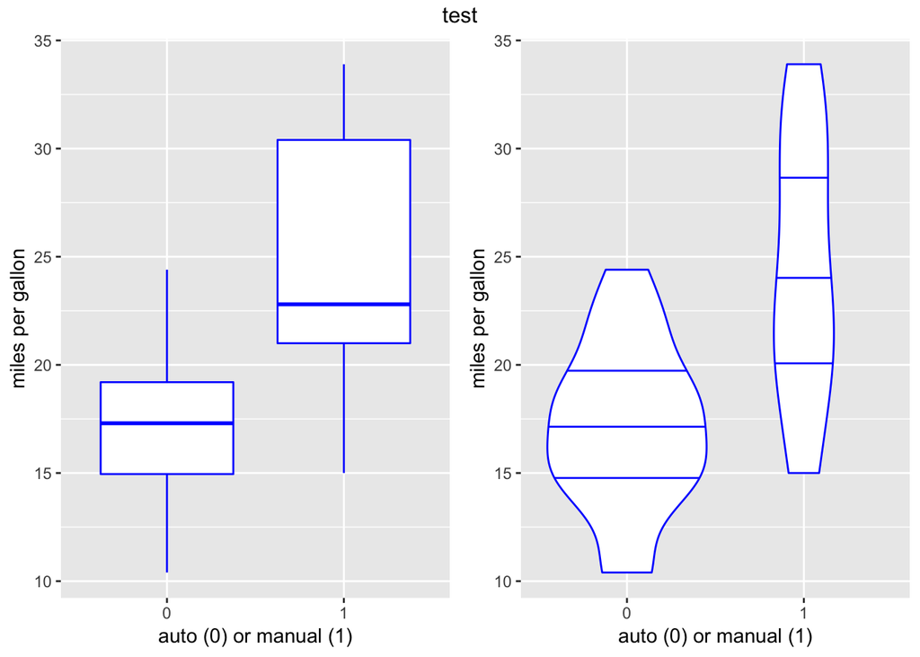

We make subgroups of the data per transmission type and perform a two-sided t-test for the null-hypothesis that the mean mpg is not different between the subgroups. At a significance level of .05, we reject this null-hypothesis, meaning there is a significant association between the transmission type and the mpg.

```
##
##  Welch Two Sample t-test
##
## data:  auto$mpg and man$mpg
## t = -3.7671, df = 18.332, p-value = 0.001374
## alternative hypothesis: true difference in means is not equal to 0
## 95 percent confidence interval:
##  -11.280194  -3.209684
## sample estimates:
## mean of x mean of y
##  17.14737  24.39231
```

We create a linear regression with the transmission type as the predictor for the mpg. We find an $R^2^$ value of .36, however, which means that only 36% of the variability of the mpg is explained by the transmission type.

```r
modAM=lm(mpg~am, mtcars)
summary(modAM)$r.square
```

```
## [1] 0.3597989
```

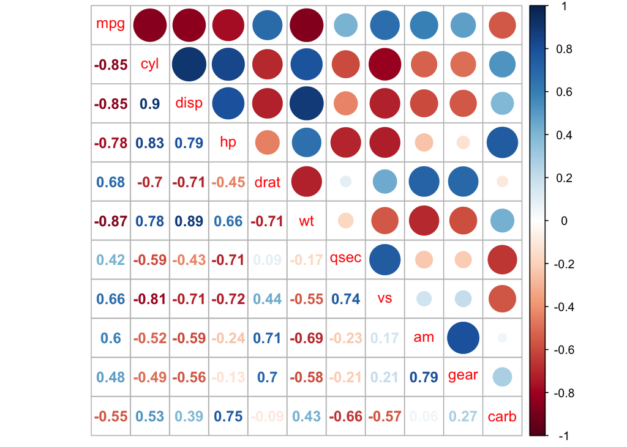

```r
correl=cor(mtcars)
diag(correl)<-0
corrplot.mixed(correl)
```

```r
#mtcars$cyl=factor(mtcars$cyl)
#mtcars$vs=factor(mtcars$vs)
#mtcars$am=factor(mtcars$am,labels=c('Auto','Man'))
#mtcars$gear=factor(mtcars$gear)
#mtcars$carb=factor(mtcars$carb)
```

[output not shown]

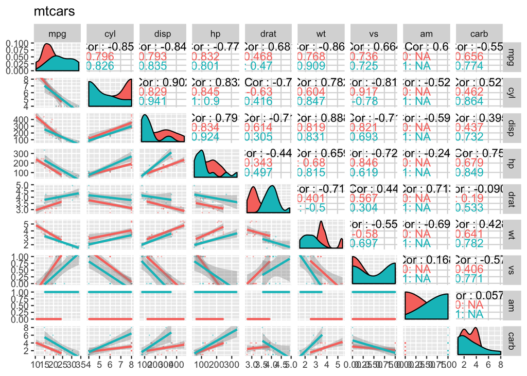

```r
selection=mtcars[,c(1,which(abs(correl[,"mpg"])>0.5))]
ggpairs(selection,lower = list(continuous=wrap("smooth",alpha=0.3,size=0.1)),title="mtcars",mapping=ggplot2::aes(color=as.factor(mtcars$am)))
```

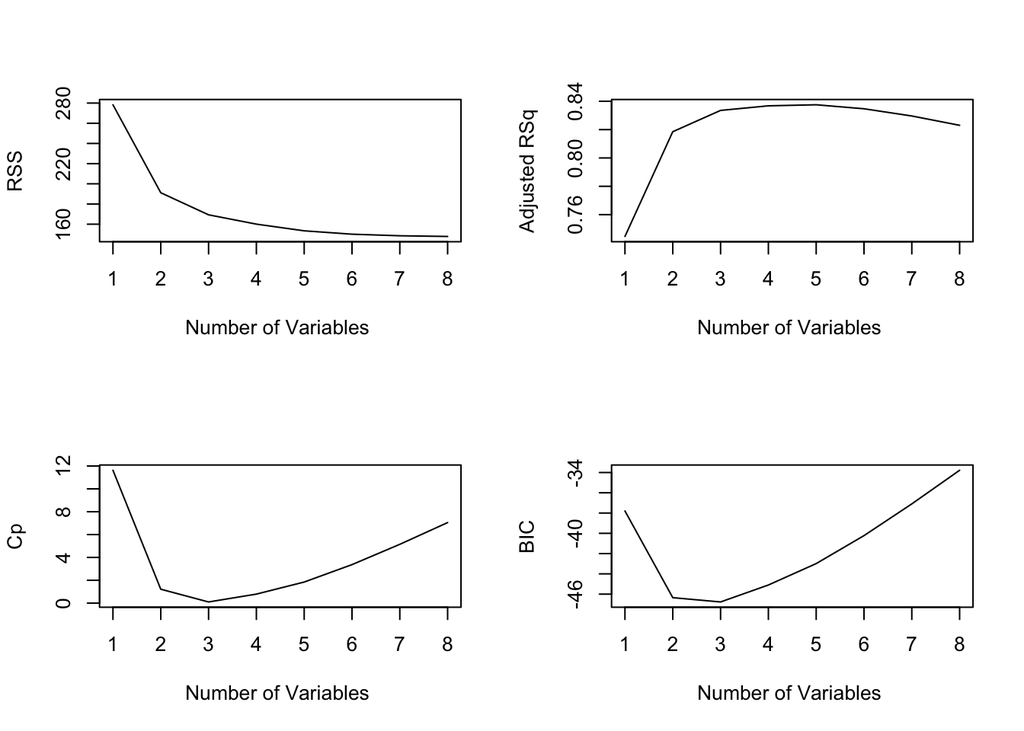

```r
regfit.full=regsubsets(mpg~.,data=mtcars)
reg.summary =summary(regfit.full)
par(mfrow=c(2,2))
plot(reg.summary$rss ,xlab="Number of Variables ",ylab="RSS", type="l")
plot(reg.summary$adjr2 ,xlab="Number of Variables ", ylab="Adjusted RSq",type="l")
plot(reg.summary$cp ,xlab="Number of Variables ",ylab="Cp",type="l")
plot(reg.summary$bic ,xlab="Number of Variables ",ylab="BIC", type="l")
```

```r
n_bic<-which.min(reg.summary$bic)
n_cp<-which.min(reg.summary$cp)
coef(regfit.full ,n_bic)
```

```
## (Intercept)          wt        qsec          am
##    9.617781   -3.916504    1.225886    2.935837
```

```r
modSel<-lm(mpg~wt+qsec+am,data=mtcars)
vif(modSel)
```

```
##       wt     qsec       am
## 2.482952 1.364339 2.541437
```

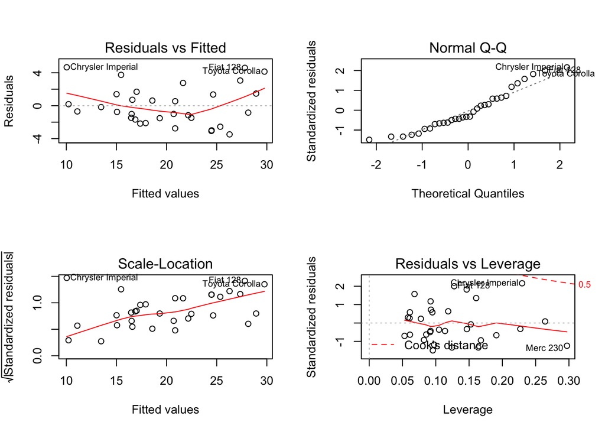

```r
par(mfrow=c(2,2))
plot(modSel)
```

```r
sum.modSel=summary(modSel)
sum.modSel$adj.r.squared
```

```
## [1] 0.8335561
```

```r
sum.modSel$r.squared
```

```
## [1] 0.8496636
```

```r
sum.modSel$coef
```

```
##              Estimate Std. Error   t value     Pr(>|t|)
## (Intercept)  9.617781  6.9595930  1.381946 1.779152e-01
## wt          -3.916504  0.7112016 -5.506882 6.952711e-06
## qsec         1.225886  0.2886696  4.246676 2.161737e-04
## am           2.935837  1.4109045  2.080819 4.671551e-02
```

```r
modAll=lm(mpg~.,mtcars)
modStepAIC=stepAIC(modAll)
```

```
## Start:  AIC=70.9
## mpg ~ cyl + disp + hp + drat + wt + qsec + vs + am + gear + carb
##
##        Df Sum of Sq    RSS    AIC
## - cyl   1    0.0799 147.57 68.915
## - vs    1    0.1601 147.66 68.932
## - carb  1    0.4067 147.90 68.986
## - gear  1    1.3531 148.85 69.190
## - drat  1    1.6270 149.12 69.249
## - disp  1    3.9167 151.41 69.736
## - hp    1    6.8399 154.33 70.348
## - qsec  1    8.8641 156.36 70.765
## <none>              147.49 70.898
## - am    1   10.5467 158.04 71.108
## - wt    1   27.0144 174.51 74.280
##
## Step:  AIC=68.92
## mpg ~ disp + hp + drat + wt + qsec + vs + am + gear + carb
##
##        Df Sum of Sq    RSS    AIC
## - vs    1    0.2685 147.84 66.973
## - carb  1    0.5201 148.09 67.028
## - gear  1    1.8211 149.40 67.308
## - drat  1    1.9826 149.56 67.342
## - disp  1    3.9009 151.47 67.750
## - hp    1    7.3632 154.94 68.473
## <none>              147.57 68.915
## - qsec  1   10.0933 157.67 69.032
## - am    1   11.8359 159.41 69.384
## - wt    1   27.0280 174.60 72.297
##
## Step:  AIC=66.97
## mpg ~ disp + hp + drat + wt + qsec + am + gear + carb
##
##        Df Sum of Sq    RSS    AIC
## - carb  1    0.6855 148.53 65.121
## - gear  1    2.1437 149.99 65.434
## - drat  1    2.2139 150.06 65.449
## - disp  1    3.6467 151.49 65.753
## - hp    1    7.1060 154.95 66.475
```

[output cut: 44 more lines]

```
##        Df Sum of Sq    RSS    AIC
## - hp    1     9.219 169.29 61.307
## <none>              160.07 61.515
## - qsec  1    20.225 180.29 63.323
## - am    1    25.993 186.06 64.331
## - wt    1    78.494 238.56 72.284
##
## Step:  AIC=61.31
## mpg ~ wt + qsec + am
##
##        Df Sum of Sq    RSS    AIC
## <none>              169.29 61.307
## - am    1    26.178 195.46 63.908
## - qsec  1   109.034 278.32 75.217
## - wt    1   183.347 352.63 82.790
```

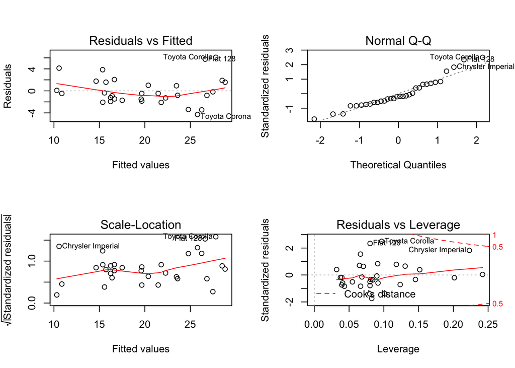

```r
modSimple2<-lm(mpg~cyl+wt,data=mtcars)
par(mfrow=c(2,2))
plot(modSimple2)
```

```r
sum.modSimple2=summary(modSimple2)
sum.modSimple2$adj.r.squared
```

```
## [1] 0.8185189
```

```r
sum.modSimple2$r.squared
```

```
## [1] 0.8302274
```

```r
sum.modSimple2$coef
```

```
##              Estimate Std. Error   t value     Pr(>|t|)
## (Intercept) 39.686261  1.7149840 23.140893 3.043182e-20
## cyl         -1.507795  0.4146883 -3.635972 1.064282e-03
## wt          -3.190972  0.7569065 -4.215808 2.220200e-04
```

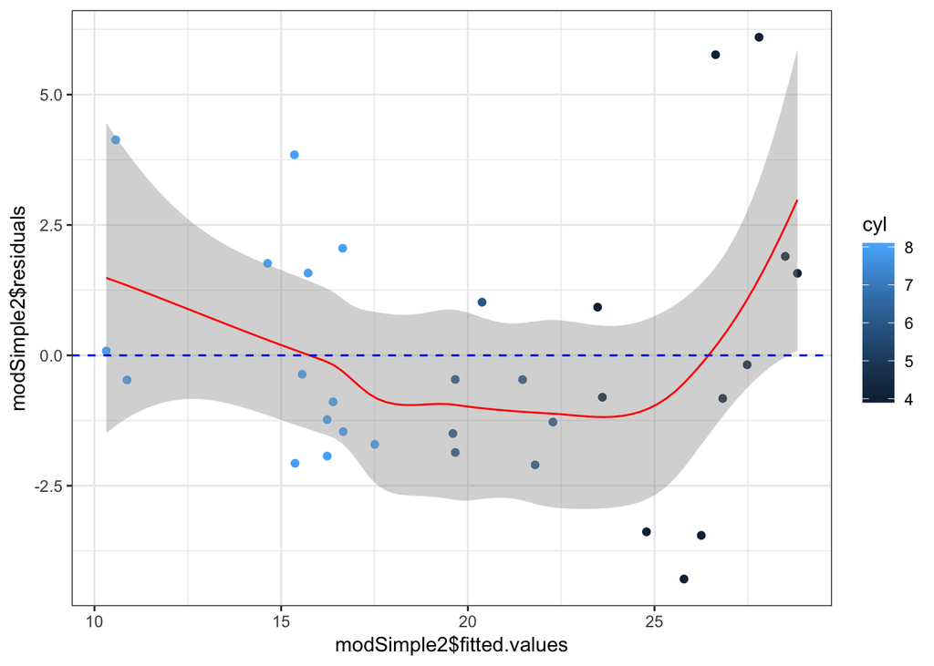

```r
g=ggplot(mtcars,aes(x=modSimple2$fitted.values,y=modSimple2$residuals, col=cyl))
g=g+geom_point()
g=g+geom_point(shape = 1) + theme_bw()
g=g+geom_smooth(method = "loess",size = .5, col="red") #, se=FALSE,
g=g+geom_hline(yintercept=0, linetype="dashed", color = "blue")
plot(g)
```

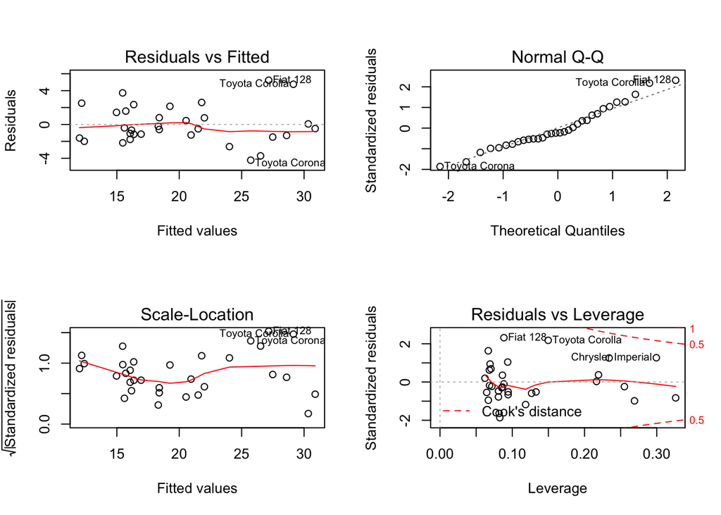

```r
modSimple3<-lm(mpg~cyl+wt+cyl*wt,data=mtcars)
par(mfrow=c(2,2))
plot(modSimple3)
```

```r
sum.modSimple3=summary(modSimple3)
sum.modSimple3$adj.r.squared
```

```
## [1] 0.8456592
```

```r
sum.modSimple3$r.squared
```

```
## [1] 0.8605954
```

```r
sum.modSimple3$coef
```

```
##               Estimate Std. Error   t value     Pr(>|t|)
## (Intercept) 54.3068062   6.127535  8.862749 1.288912e-09
## cyl         -3.8032187   1.005028 -3.784193 7.471791e-04
## wt          -8.6555590   2.320122 -3.730648 8.609666e-04
## cyl:wt       0.8083947   0.327322  2.469723 1.988242e-02
```

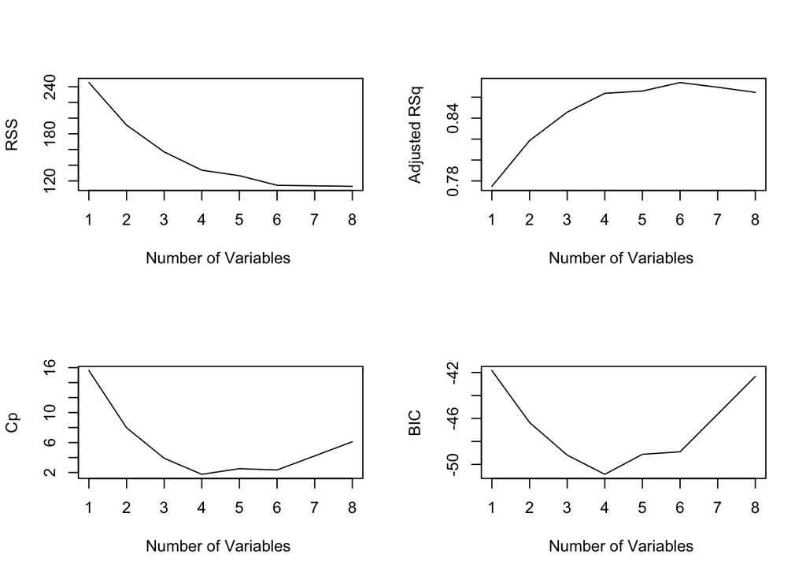

```r
regfit.full2=regsubsets(mpg~.+cyl*wt,data=mtcars)
reg.summary2=summary(regfit.full2)
par(mfrow=c(2,2))
plot(reg.summary2$rss ,xlab="Number of Variables ",ylab="RSS", type="l")
plot(reg.summary2$adjr2 ,xlab="Number of Variables ", ylab="Adjusted RSq",type="l")
plot(reg.summary2$cp ,xlab="Number of Variables ",ylab="Cp",type="l")
plot(reg.summary2$bic ,xlab="Number of Variables ",ylab="BIC", type="l")
```

```r
n_bic<-which.min(reg.summary2$bic)
n_cp<-which.min(reg.summary2$cp)
coef(regfit.full2 ,n_bic)
```

```
## (Intercept)         cyl          wt        qsec      cyl:wt
##   41.642888   -3.392655  -10.819534    0.757161    0.976600
```

```r
modSel2<-lm(mpg~wt+cyl+wt*cyl+qsec,data=mtcars)
vif(modSel2)
```

```
##        wt       cyl      qsec    wt:cyl
## 34.462240 18.529641  2.435981 77.904675
```

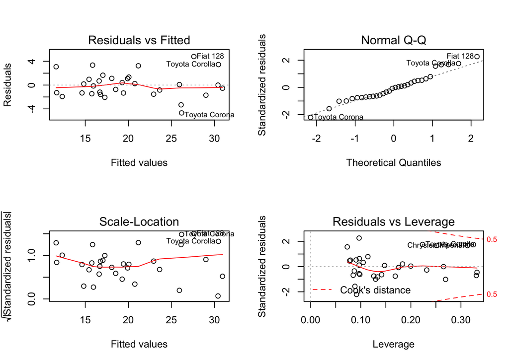

```r
par(mfrow=c(2,2))
plot(modSel2)
```

```r
summary(modSel2)
```

```
##
## Call:
## lm(formula = mpg ~ wt + cyl + wt * cyl + qsec, data = mtcars)
##
## Residuals:
##     Min      1Q  Median      3Q     Max
## -4.6822 -1.3668 -0.0789  1.0943  4.7947
##
## Coefficients:
##             Estimate Std. Error t value Pr(>|t|)
## (Intercept)  41.6429     8.2002   5.078 2.47e-05 ***
## wt          -10.8195     2.3977  -4.512 0.000113 ***
## cyl          -3.3927     0.9633  -3.522 0.001543 **
## qsec          0.7572     0.3491   2.169 0.039044 *
## wt:cyl        0.9766     0.3172   3.079 0.004735 **
## ---
## Signif. codes:  0 '***' 0.001 '**' 0.01 '*' 0.05 '.' 0.1 ' ' 1
##
## Residual standard error: 2.225 on 27 degrees of freedom
## Multiple R-squared:  0.8813, Adjusted R-squared:  0.8637
## F-statistic: 50.11 on 4 and 27 DF,  p-value: 4.134e-12
```

```r
#mtcars$cyl=factor(mtcars$cyl)
#mtcars$vs=factor(mtcars$vs)
#mtcars$am=factor(mtcars$am,labels=c('Auto','Man'))
#mtcars$gear=factor(mtcars$gear)
#mtcars$carb=factor(mtcars$carb)
```

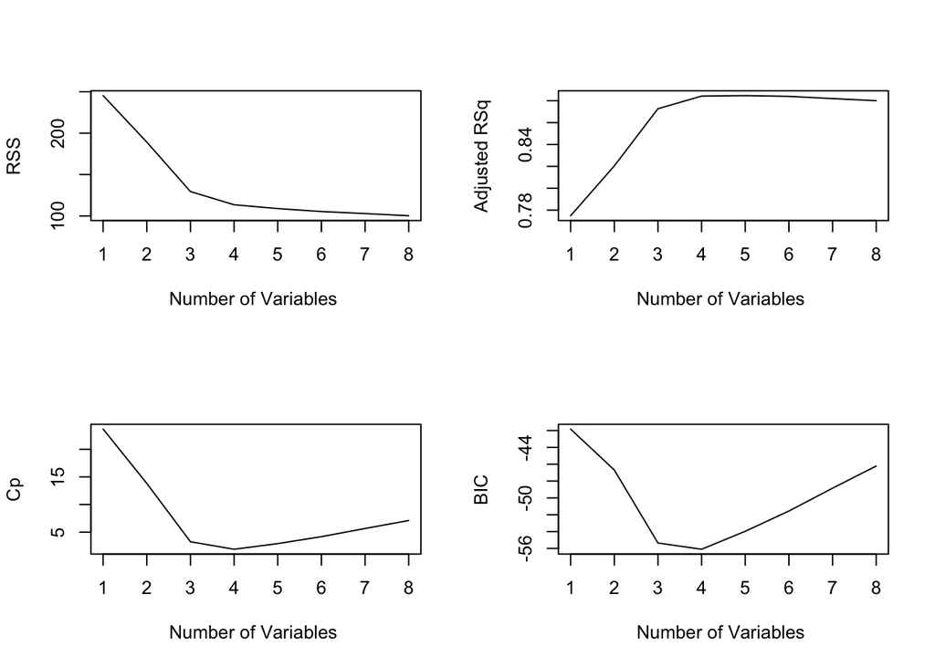

```r
regfit.full2=regsubsets(mpg~(cyl+wt+qsec+am)^2,data=mtcars)
reg.summary2=summary(regfit.full2)
par(mfrow=c(2,2))
plot(reg.summary2$rss ,xlab="Number of Variables ",ylab="RSS", type="l")
plot(reg.summary2$adjr2 ,xlab="Number of Variables ", ylab="Adjusted RSq",type="l")
plot(reg.summary2$cp ,xlab="Number of Variables ",ylab="Cp",type="l")
plot(reg.summary2$bic ,xlab="Number of Variables ",ylab="BIC", type="l")
```

```r
n_bic<-which.min(reg.summary2$bic)
n_cp<-which.min(reg.summary2$cp)
coef(regfit.full2 ,n_bic)
```

```
## (Intercept)        qsec          am     wt:qsec       wt:am
##   0.7758419   1.5278652  13.8815255  -0.1676637  -4.1009839
```

```r
modSel2<-lm(mpg~qsec+am+wt/am,data=mtcars)
vif(modSel2)
```

```
##      qsec        am        wt     am:wt
##  1.447406 20.970925  3.030963 16.302453
```

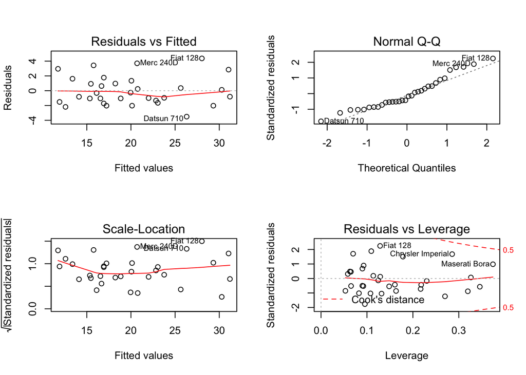

```r
par(mfrow=c(2,2))
plot(modSel2)
```

```r
summary(modSel2)
```

```
##
## Call:
## lm(formula = mpg ~ qsec + am + wt/am, data = mtcars)
##
## Residuals:
##     Min      1Q  Median      3Q     Max
## -3.5076 -1.3801 -0.5588  1.0630  4.3684
##
## Coefficients:
##             Estimate Std. Error t value Pr(>|t|)
## (Intercept)    9.723      5.899   1.648 0.110893
## qsec           1.017      0.252   4.035 0.000403 ***
## am            14.079      3.435   4.099 0.000341 ***
## wt            -2.937      0.666  -4.409 0.000149 ***
## am:wt         -4.141      1.197  -3.460 0.001809 **
## ---
## Signif. codes:  0 '***' 0.001 '**' 0.01 '*' 0.05 '.' 0.1 ' ' 1
##
## Residual standard error: 2.084 on 27 degrees of freedom
## Multiple R-squared:  0.8959, Adjusted R-squared:  0.8804
## F-statistic: 58.06 on 4 and 27 DF,  p-value: 7.168e-13
```

[output not shown]